# Final project

Alexzanah Griffin

4/21/2023

Analyze large data and load in data

```r
#make paths

broadpeakfilepath <- "/scratch/Shares/rinnclass/CLASS_2023/data/data/peaks"

all_peaks_list <- import_peaks(consensus_file_path = broadpeakfilepath)

#peak_list <- import_peaks(consensus_file_path = broadpeakfilepath)
```

```r
# How does peak number and genome coverage compare (need gencode)

#Gene annotations
gencode_gr <- rtracklayer::import("/scratch/Shares/rinnclass/CLASS_2023/data/data/genomes/gencode.v32.annotation.gtf")

gencode_genes <- gencode_gr[gencode_gr$type == "gene"]
table(gencode_gr$type)
```

```
##
##           gene     transcript           exon            CDS    start_codon
##          60609         227462        1372308         761508          87662
##     stop_codon            UTR Selenocysteine
##          79913         310193            119
```

```r
# exporting all genes file
rtracklayer::export(gencode_genes, "results/gene_annotations/gencode_genes.gtf")

#mrna
mrna_genes <- gencode_genes[gencode_genes$gene_type %in% "protein_coding"]

rtracklayer::export(mrna_genes, "results/gene_annotations/mrna_genes.gtf")
table(gencode_genes$gene_type)
```

```
##
##                          IG_C_gene                    IG_C_pseudogene
##                                 14                                  9
##                          IG_D_gene                          IG_J_gene
##                                 37                                 18
##                    IG_J_pseudogene                      IG_pseudogene
##                                  3                                  1
##                          IG_V_gene                    IG_V_pseudogene
##                                144                                188
##                             lncRNA                              miRNA
##                              16849                               1881
##                           misc_RNA                            Mt_rRNA
##                               2212                                  2
##                            Mt_tRNA             polymorphic_pseudogene
##                                 22                                 42
##               processed_pseudogene                     protein_coding
##                              10171                              19965
##                         pseudogene                           ribozyme
##                                 18                                  8
##                               rRNA                    rRNA_pseudogene
##                                 52                                500
##                             scaRNA                              scRNA
##                                 49                                  1
##                             snoRNA                              snRNA
##                                942                               1901
##                               sRNA                                TEC
##                                  5                               1061
##                          TR_C_gene                          TR_D_gene
##                                  6                                  4
##                          TR_J_gene                    TR_J_pseudogene
##                                 79                                  4
##                          TR_V_gene                    TR_V_pseudogene
##                                106                                 33
##   transcribed_processed_pseudogene     transcribed_unitary_pseudogene
##                                495                                130
## transcribed_unprocessed_pseudogene    translated_processed_pseudogene
##                                923                                  2
##  translated_unprocessed_pseudogene                 unitary_pseudogene
##                                  2                                 98
##             unprocessed_pseudogene                           vaultRNA
##                               2631                                  1
```

```r
#lncrna
lncrna_genes <- gencode_genes[gencode_genes$gene_type %in% "lncRNA"]
rtracklayer::export(lncrna_genes, "results/gene_annotations/lncrna_genes.gtf")

#both mrna and lncrna <3
mrna_lncrna_genes <- gencode_genes[gencode_genes$gene_type %in% c("protein_coding","lncRNA")]
rtracklayer::export(mrna_lncrna_genes, "results/gene_annotations/mrna_lncrna_genes.gtf")

# mrna & lncrna annotation
lncrna_mrna_genes <- rtracklayer::import("results/gene_annotations/mrna_lncrna_genes.gtf")

#easier to see as df
lncrna_mrna_genes_df <- lncrna_mrna_genes %>% as.data.frame()

#promoter annotations set promoter size and save as df
lncrna_mrna_promoters <- promoters(lncrna_mrna_genes, upstream = 1000, downstream = 1000)

lncrna_mrna_promoters_df <-lncrna_mrna_promoters %>% as.data.frame()

rtracklayer::export(lncrna_mrna_promoters, "results/gene_annotations/lncrna_mrna_promoters.gtf")

#lncrna geneIDs
lncrna_gene_ids <- mrna_lncrna_genes$gene_id[mrna_lncrna_genes$gene_type == "lncRNA"]
table(mrna_lncrna_genes$gene_type)
```

```
##
##         lncRNA protein_coding
##          16849          19965
```

```r
#mrna geneIDs
mrna_gene_ids <-mrna_lncrna_genes$gene_id[mrna_lncrna_genes$gene_type == "protein_coding"]
```

#Make our peak data files

```r
#how many peaks do i have in my files?
peak_num <- sapply(all_peaks_list, length) %>% as.data.frame(row.names = T)
names(peak_num) <- c("num_peaks")

peak_num <- peak_num %>%
  rownames_to_column(var = "dbp") %>%
  separate(col = dbp,  into = c('dbp', 'replicate'), sep = "_")

#save this
#write_csv(peak_num, "results/num_peaks_df.csv")

#how many consensus peaks do I have (make consensus peak list)
dbps <- unique(sapply(names(all_peaks_list), function(x) {
   unlist(strsplit(x, "_"))[1]
}))

consensus_list <- lapply(dbps, consensus_from_reduced, all_peaks_list)

names(consensus_list) <- dbps

#how many consensus peaks do we have per gene
num_consensus_peaks <- sapply(consensus_list, length) %>%
  as.data.frame() %>%
  rownames_to_column( var = "dbp") %>%
  dplyr::rename(consensus_peaks = ".")

#Add consensus into peak_num df
num_peaks <- sapply(consensus_list, length)

peak_num <- left_join(peak_num, num_consensus_peaks)
names(peak_num)[4] <- "total_consensus"
```

#filter consensus peaks

```r
#filter out data with less that 1000 peaks so make a filtered consensus peaks
filtered_consensus_list <- consensus_list[num_peaks >= 1000]


filtered_consensus_lower_list <- consensus_list[num_peaks < 1000]

#make a df
filtered_consensus_df <- sapply(filtered_consensus_list, length) %>%
  as.data.frame() %>%
  rownames_to_column( var = "dbp") %>%
  dplyr::rename(consensus_peaks = ".")

filtered_consensus_lower_df <- sapply(filtered_consensus_lower_list, length) %>%
  as.data.frame() %>%
  rownames_to_column( var = "dbp") %>%
  dplyr::rename(consensus_peaks = ".")


#save
#write_csv(filtered_consensus_df, "results/filtered_consensus_df.csv")
#write_csv(filtered_consensus_lower_df,"results/consensus_lower_df.csv")
```

#what is the peak genome coverage?

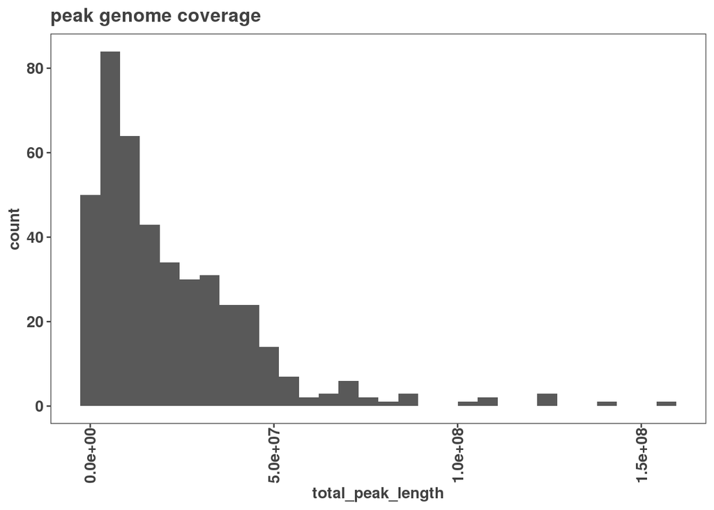

```r
# Now we can do this: How does peak number and genome coverage compare (use consnesus_kist (grange obj) dont use dfs)
num_peaks_df <- data.frame("dbp" = names(filtered_consensus_list),
                           "num_peaks" = sapply(filtered_consensus_list, length))


num_peaks_df$total_peak_length <- sapply(filtered_consensus_list, function(x) sum(width(x)))


#Total genome coverage histogram

ggplot(num_peaks_df, aes(x = total_peak_length)) +
  geom_histogram(bins = 30) +
  ggtitle("peak genome coverage")
```

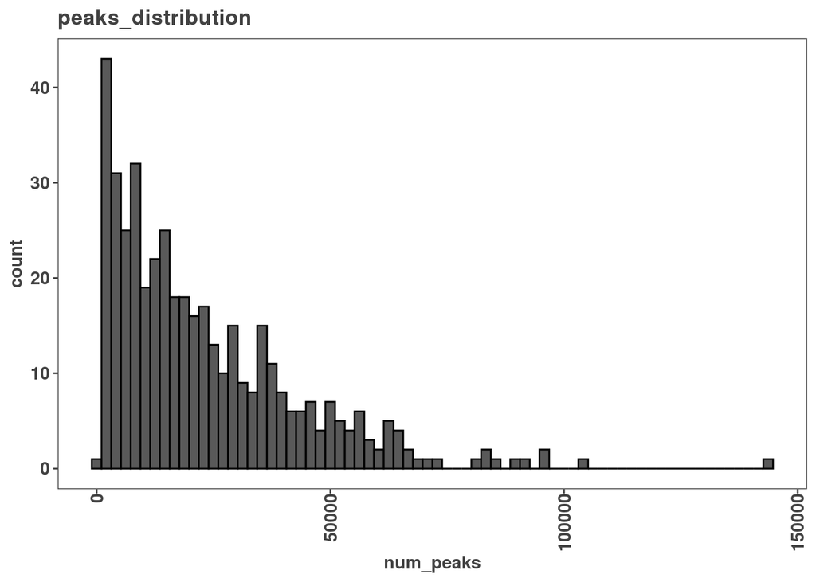

```r
#save
#ggsave("figures/peaks_v_genome_coverage_hist.pdf")

#peak distribution on dbps
 ggplot(num_peaks_df, aes(x = num_peaks)) +
  geom_histogram(bins = 70, color = "black") +
   ggtitle("peaks_distribution")
```

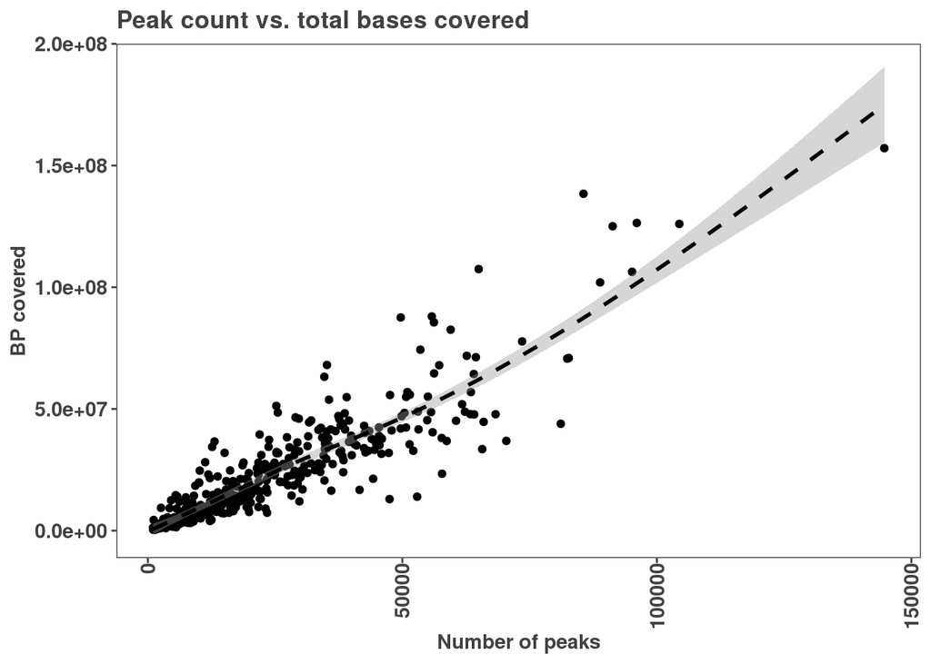

```r
# saving
#ggsave("figures/peaks_distribution_hist.pdf")

#scatterplot
ggplot(num_peaks_df, aes(x = num_peaks, y = total_peak_length)) +
  geom_point() +
  geom_smooth(method = "gam", se = TRUE, color = "black", lty = 2)+

  ylab("BP covered") +
  xlab("Number of peaks") +
  ggtitle("Peak count vs. total bases covered")
```

```r
#ggsave("figures/peak_vs_coverage_scatter.pdf")
```

#results ##The bulk of peaks are shorter and cover less of the genome(<50,000),But there are some (very few) peaks that are larger and cover more of the genome. ## there is a linear relationship between genome coverage and peak number.

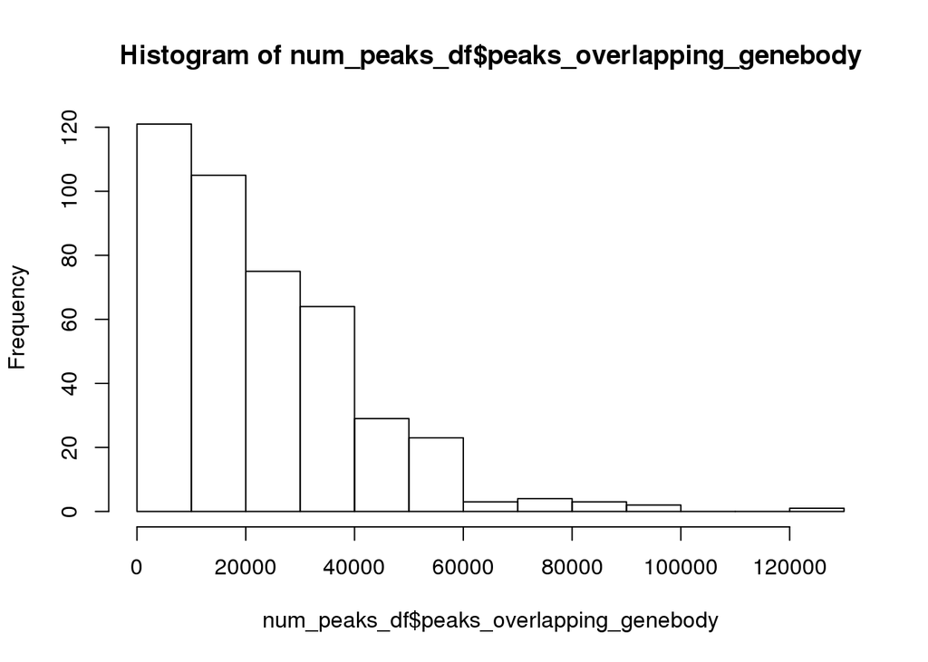

```r
#genebody peak counts
genebody_peak_counts <- count_peaks_per_feature(mrna_lncrna_genes,
                                                filtered_consensus_list,
                                                type = "counts")

#overlapping peaks to total genebodies
num_peaks_df$peaks_overlapping_genebody <- rowSums(genebody_peak_counts)

#lncrna to genebodies
num_peaks_df$peaks_overlapping_lncrna_genebody <- rowSums(genebody_peak_counts[,lncrna_gene_ids])

# mRNA gene bodies
num_peaks_df$peaks_overlapping_mrna_genebody <- rowSums(genebody_peak_counts[,mrna_gene_ids])

#write_csv(num_peaks_df, "results/num_peaks_df.csv")

#now lets look at it (peaks v. genebodies)
hist(num_peaks_df$peaks_overlapping_genebody)
```

```r
#SAVE MEE
ggsave("figures/peak_vs_genebody.pdf")
# all rna genebody overlaps
num_peaks_df$percent_total_genebody_overlaps <- (num_peaks_df$peaks_overlapping_genebody/36814)*100
percent_genebody_overlaps <- mean(num_peaks_df$percent_total_genebody_overlaps)

print(paste0(percent_genebody_overlaps, "%", " of peaks overlap total genebody"))
```

```
## [1] "62.2646781242222% of peaks overlap total genebody"
```

```r
# % of lncrna genebody overlaps
num_peaks_df$percent_lncrna_genebody_overlaps <- (num_peaks_df$peaks_overlapping_lncrna_genebody/36814)*100
percent_lncrna_genebody_overlaps <- mean(num_peaks_df$percent_lncrna_genebody_overlaps)

print(paste0(percent_lncrna_genebody_overlaps, "%", " of peaks overlap lncrna genebody"))
```

```
## [1] "12.9164208257475% of peaks overlap lncrna genebody"
```

```r
# % of mrna genebody overlaps
num_peaks_df$percent_mrna_genebody_overlaps <- (num_peaks_df$peaks_overlapping_mrna_genebody/36814)*100
percent_mrna_genebody_overlaps <- mean(num_peaks_df$percent_mrna_genebody_overlaps)

print(paste0(percent_mrna_genebody_overlaps, "%", " of peaks overlap mrna genebody"))
```

```
## [1] "49.3482572984747% of peaks overlap mrna genebody"
```

#peak promoter coverage?

```r
# What is the distribution of promoter overlaps versus gene-bodies (hint hist)
#promoter and peak overlaps (matrix)
promoter_peak_counts <- count_peaks_per_feature(lncrna_mrna_promoters, filtered_consensus_list, type = "counts")

#matrix
promoter_peak_occurrence_matrix <- count_peaks_per_feature(lncrna_mrna_promoters, filtered_consensus_list, type = "occurrence")

#make peak occurrnce df
promoter_peak_occurrence_df <-data.frame("gene_id" = colnames(promoter_peak_counts),
  "gene_name" = lncrna_mrna_promoters$gene_name,
  "gene_type" = lncrna_mrna_promoters$gene_type,
  "chr" = lncrna_mrna_promoters@seqnames,
  "1kb_up_tss_start" = lncrna_mrna_promoters@ranges@start,
  "strand" = lncrna_mrna_promoters@strand,
  "number_of_dbp" = colSums(promoter_peak_counts))

#write_csv(promoter_peak_occurrence_df, "results/promoter_peak_occurrence_df.csv")
```

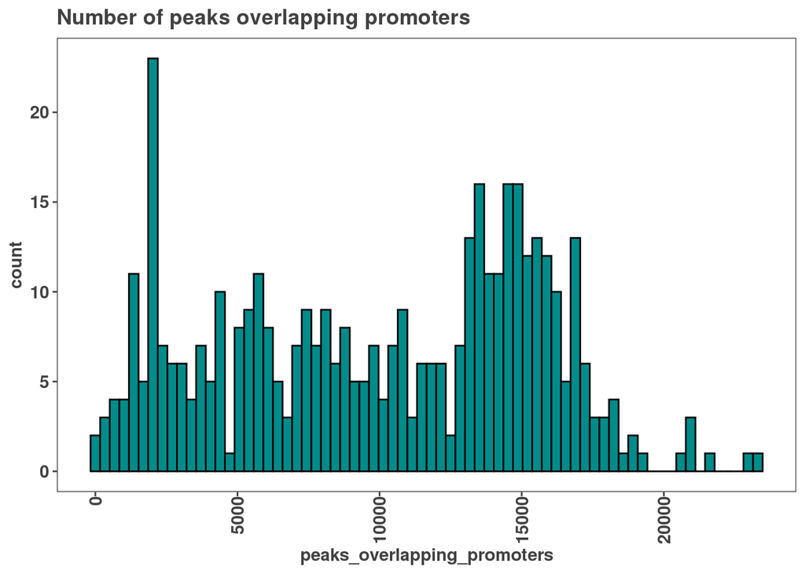

```r
#peaks overlapping promoters
num_peaks_df$peaks_overlapping_promoters <- rowSums(promoter_peak_counts)

# lncrna promoter overlaps
num_peaks_df$peaks_overlapping_lncrna_promoters <- rowSums(promoter_peak_counts[,lncrna_gene_ids])

# mrna promoter overlaps
num_peaks_df$peaks_overlapping_mrna_promoters <- rowSums(promoter_peak_counts[,mrna_gene_ids])

#peaks vs promoters histogram
ggplot(num_peaks_df, aes(peaks_overlapping_promoters))+
  ggtitle("Number of peaks overlapping promoters")+
  geom_histogram(bins = 70, fill = "cyan4", color = "black")
```

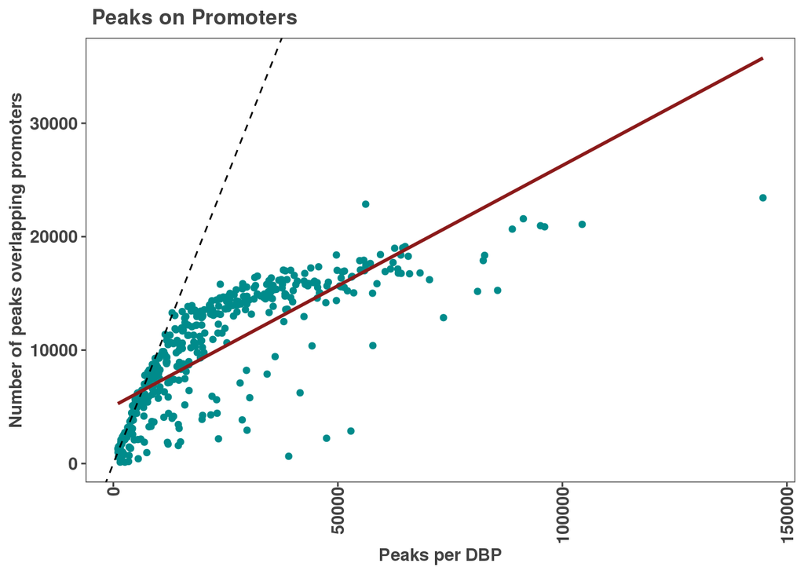

```r
#hist(num_peaks_df$peaks_overlapping_promoters)

#ggsave("figures/peaks_v_promoters.pdf")

#scatterplot
ggplot(num_peaks_df,
       aes(x = num_peaks, y = peaks_overlapping_promoters)) +
  xlab("Peaks per DBP") +
  ylab("Number of peaks overlapping promoters") +
  ggtitle(" Peaks on Promoters")+
  geom_point(color = "cyan4") +
  geom_abline(slope = 1, linetype="dashed") +
  geom_smooth(method = "lm", se=FALSE, formula = 'y ~ x',
              color = "firebrick4")
```

```r
#ggsave("figures/peaks_v_promoters_scatter.pdf")

#Density plot (may not need this)
#ggplot(promoter_peak_occurrence_df, aes(x = number_of_dbp)) +
#geom_density(alpha = 0.2, color = "black", fill = "cyan4") +
  #theme_paperwhite() +
#  xlab(expression("Number of DBPs")) +
 # ylab(expression("Density")) +
  #ggtitle("Promoter binding events",
   #       subtitle = "mRNA and lncRNA genes")

# Avg promoter overlaps
#total_num_peaks <- sum(num_peaks_df$num_peaks)

# all promoter overlaps
num_peaks_df$percent_total_promoter_overlaps <- (num_peaks_df$peaks_overlapping_promoters/36814)*100
percent_promoter_overlaps <- mean(num_peaks_df$percent_total_promoter_overlaps)

print(paste0(percent_promoter_overlaps, "%", "of peaks overlap promoters"))
```

```
## [1] "27.2122081968311%of peaks overlap promoters"
```

```r
# % of lncrna promoter overlaps
num_peaks_df$percent_lncrna_promoter_overlaps <- (num_peaks_df$peaks_overlapping_lncrna_promoters/36814)*100
percent_lncrna_promoter_overlaps <- mean(num_peaks_df$percent_lncrna_promoter_overlaps)

print(paste0(percent_lncrna_promoter_overlaps, "%", "of peaks overlap lncrna promoters"))
```

```
## [1] "6.62486844615484%of peaks overlap lncrna promoters"
```

```r
# % of mrna promoter overlaps
num_peaks_df$percent_mrna_promoter_overlaps <- (num_peaks_df$peaks_overlapping_mrna_promoters/36814)*100
percent_mrna_promoter_overlaps <- mean(num_peaks_df$percent_mrna_promoter_overlaps)

print(paste0(percent_mrna_promoter_overlaps, "%", "of peaks overlap mrna promoters"))
```

```
## [1] "20.5873397506762%of peaks overlap mrna promoters"
```

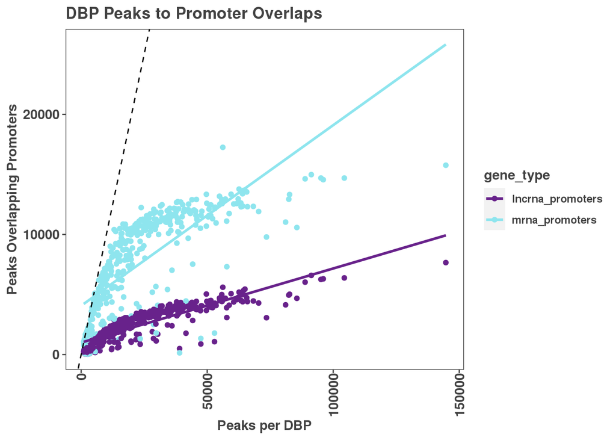

```r
#lnc V mRNA
lncrna_vs_mrna_overlaps <- num_peaks_df %>%
  dplyr::select(-peaks_overlapping_promoters) %>%
  pivot_longer(cols = peaks_overlapping_lncrna_promoters:peaks_overlapping_mrna_promoters,
               names_to = "gene_type",
               values_to = "peaks_overlapping_promoters") %>%
  mutate(gene_type = gsub("peaks_overlapping_", "", gene_type))

# plotting lncrna mrna
ggplot(lncrna_vs_mrna_overlaps, aes(x = num_peaks, y = peaks_overlapping_promoters,
                         col = gene_type)) +
         geom_point() +
         geom_abline(slope = 1, linetype="dashed") +
  geom_smooth(method = "lm", se = FALSE, formula = "y ~ x") +
  scale_color_manual(values = c("darkorchid4", "cadetblue2"))+
  xlab("Peaks per DBP") +
  ylab("Peaks Overlapping Promoters") +
  ggtitle("DBP Peaks to Promoter Overlaps")
```

```r
# saving
#ggsave("figures/peaks_overlaps_by_gene_type.pdf")
```

#results ## mrna starts to plateu after reaching a peak DBP coverage before 50,000. While promoters overlapping lncrna per DBP hals plateues, it’s not as dramatic as the mrna promoters.

#Lets look at superbinders

```r
# Make a list of genes that are "super binders" (peak feats counts peaks/feature counts and occurence [peaks that have more than 200 bound to promoter(could be more up to u)])
#super_binder_threshold <- 200
super_binder <- filter(promoter_peak_occurrence_df, number_of_dbp>= 200)

#write_csv(super_binder, "results/super_binders.csv")

#lncrna superbinders
lncrna_super_binders <- filter(super_binder, gene_type == "lncRNA" )
length(lncrna_super_binders)
```

```
## [1] 7
```

```r
#mrna superbinders
mrna_super_binders <- filter(super_binder, gene_type == "protein_coding" )
length(mrna_super_binders)
```

```
## [1] 7
```

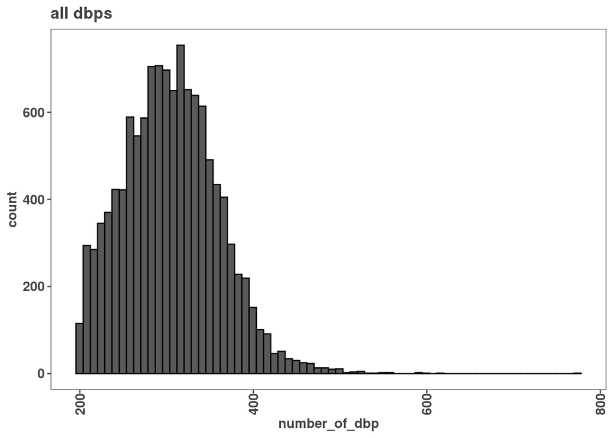

```r
#hist of superbinders
ggplot(super_binder, aes(number_of_dbp))+
  ggtitle("all dbps")+
  geom_histogram(bins = 70, color = "black")
```

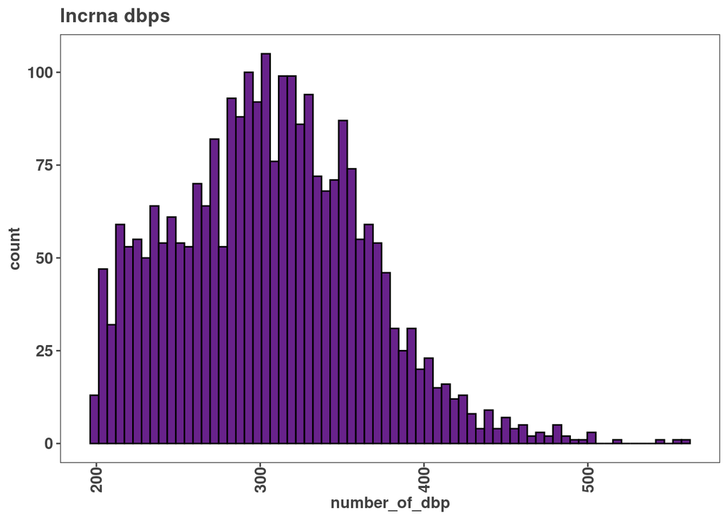

```r
#ggsave("hist_all_superbinders.pdf")

#lncrna
ggplot(lncrna_super_binders, aes(number_of_dbp))+
  ggtitle("lncrna dbps")+
  geom_histogram(bins = 70, fill = "darkorchid4", color = "black")
```

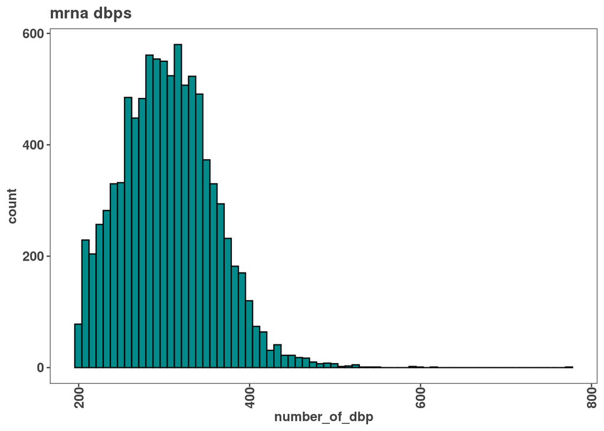

```r
#ggsave("hist_lncrna_superbinders.pdf")

#mrna
ggplot(mrna_super_binders, aes(number_of_dbp))+
  ggtitle("mrna dbps")+
  geom_histogram(bins = 70, fill = "cyan4", color = "black")
```

```r
#ggsave("hist_mrna_superbinders.pdf")
```

#results: (explain your findings of each section) ##the super binder threshold is 200 DBPs ##Do lncRNAs also have super-binding promoters? ####yes ##lncrna DBPs are more distributed. However mrna DBPs are more localized to the DBPs they bind to and more are binding on the DBPs.

# Clustering

```r
# dbps on promoters object
DBPs_on_promoter <- lncrna_mrna_promoters %>%
                    as.data.frame() %>%
  dplyr::select(gene_id, gene_name)

#df for promoter dbps
promoter_dbps <- promoter_peak_occurrence_matrix %>%
  as.data.frame() %>%
  rownames_to_column("dbp") %>%
pivot_longer(2:ncol(.), names_to = "gene_id", values_to = "occurrence") %>%
  filter(occurrence == 1) %>%
  dplyr::select(-occurrence) %>%
  left_join(DBPs_on_promoter)
write.table(promoter_dbps, "results/promoter_dbps.tsv")

#save as df too
promoter_dbps_df <- promoter_dbps %>% as.data.frame()

write.csv(promoter_dbps, "results/promoter_dbps.csv")

#ARID3A promoter dbps
arid_promoter <- promoter_dbps %>%
  filter(gene_name == "ARID3A")
```

```r
# creating distance matrix
peak_occurrence_dist <- dist(promoter_peak_occurrence_matrix, method = "binary")

#cluster distance matrix
bin_hier <- hclust(peak_occurrence_dist, method = "complete")

promoter_dbps <- promoter_peak_occurrence_matrix %>%
  as.data.frame() %>%
  rownames_to_column("dbp") %>%
pivot_longer(2:ncol(.), names_to = "gene_id", values_to = "occurrence") %>%
  filter(occurrence == 1) %>%
  dplyr::select(-occurrence) %>%
  left_join(DBPs_on_promoter)
```

[figure not shown]

```r
#dendrogram chart of binding profies via promoters
ggdendro::ggdendrogram(bin_hier, rotate = FALSE,  size = 3,
                       theme_dendro = TRUE) +
   coord_flip() +
   scale_y_continuous() +
   scale_x_continuous(position = "top") +
   scale_x_continuous(breaks = seq_along(bin_hier$labels[bin_hier$order]),
             labels = bin_hier$labels[bin_hier$order], position = "top",
             expand = c(0,0)) +
   theme(axis.text.x = element_text(angle = 90, hjust  = 1)) +
   theme(axis.text.y = element_text(angle = 0,hjust = 1)) +
   scale_y_reverse(expand = c(0.01, 0)) +
   theme(
     plot.background = element_blank(),
     panel.grid.major = element_blank(),
   panel.grid.minor = element_blank(),
     panel.border = element_blank()
   )
```

```r
#ggsave("figures/promoter_overlap_dendrogram.pdf", limitsize = FALSE, height = 55, width = 12)



# if we cluster by lncRNA and mRNA !!!seperately!!! what are some similarities and differences?
```

[figure not shown]

```r
# make lnc and mrna promoters objects
lncrna_promoters <- lncrna_mrna_promoters[lncrna_mrna_promoters$gene_type %in% "lncRNA"]

mrna_promoters <- lncrna_mrna_promoters[lncrna_mrna_promoters$gene_type %in% "protein_coding"]

# separate peak_occurrence_matrix into the 2 rna types
lncrna_peak_occurrence <- promoter_peak_occurrence_matrix[,lncrna_promoters$gene_id]

mrna_peak_occurrence <- promoter_peak_occurrence_matrix[,mrna_promoters$gene_id]

# make individual distance matrix
bin_hier_lncrna <- hclust(dist(lncrna_peak_occurrence, method = "binary"))

bin_hier_mrna <- hclust(dist(mrna_peak_occurrence, method = "binary"))

# plot with ggdendro (lncrna)
ggdendro::ggdendrogram(bin_hier_lncrna, rotate = T,  size = 3)
```

[figure not shown]

```r
#ggsave("figures/promoter_lncrna_overlap_dendrogram.pdf", limitsize = FALSE, height = 55, width = 12)

# plot with ggdendro (mrna)
ggdendro::ggdendrogram(bin_hier, rotate = TRUE,  size = 3)
```

```r
#ggsave("figures/promoter_mrna_overlap_dendrogram.pdf", limitsize = FALSE, height = 55, width = 12)
```

#Results ##General Clusters: ### I was suprised to see that ARIDs didnt cluster togeteher at all considering they have overlap in the cancers/tumors they help to regulate. ### ZNFs are scattered through out as is expected with their varying functions and many unknown ones. ##RNA clusters: ### In both lnc and mRNA ARIDs stay in the same general cluster group (i.e. ARID3A clusters with JUN and JUND), their closeness does change slightly however.